# Introduction to Accessibility

Carole Voulgaris

# What is accessibilty?

**The ease with which a person can fully participate in the economic, civic, and social life of their society**

Accessibility can be described in terms of two components: *mobility* and *proximity* (information connectivity could be a third component, since it allows people to participate in activities without traveling).

**Mobility** is the ease of travel. You might also think of it as the inverse of the cost of travel. The primary cost of movement is generally travel time, but it might be appropriate to consider other costs as well, such as discomfort or monetary cost.

**Mobility is determined by the transportation network.**

Ways to increase mobility

- Increase vehicle speeds (for drivers)
- Increase transit frequency and covereage (for transit riders)
- Increase route directness (for pedestrians)

Speed, travel time, and delay are generally the most common mobility metrics, but they are characteristics of routes and transportation facilities, rather than being characteristics of sites.

A useful site-level mobility metric might be the total area (e.g. in square kilometers) that can be reached within a unit of time (i.e. the area of an *isochrone*), and that’s what I’ll use for this discussion.

**Proximity** is the distance between a person and the locations of all the activities they might want to participate in.

**Proximity is determined by land use patterns.**

The proximity component of accessibility is commonly described in terms of densities (e.g. number of jobs per square kilometer).

**Relationships among proximity, mobility, and accessibilty**

Using the following definitions:

- Mobility = The total area that is reachable within a unit of time,
- Proximity = The total number of opportunities within that area, and
- Accessibility = The total number of opportunities that are reachable within a unit of time,

$Accessibility = Mobility\times Proximity$

This means you can increase accessibility by increasing either mobility or proximity, but be careful. Particularly for cars, increases in mobility are often accompanied by counteracting reductions in proximity, and vice versa.

# Example: 3 sites in the Seattle area

[interactive chart not shown]

## Differences in mobility

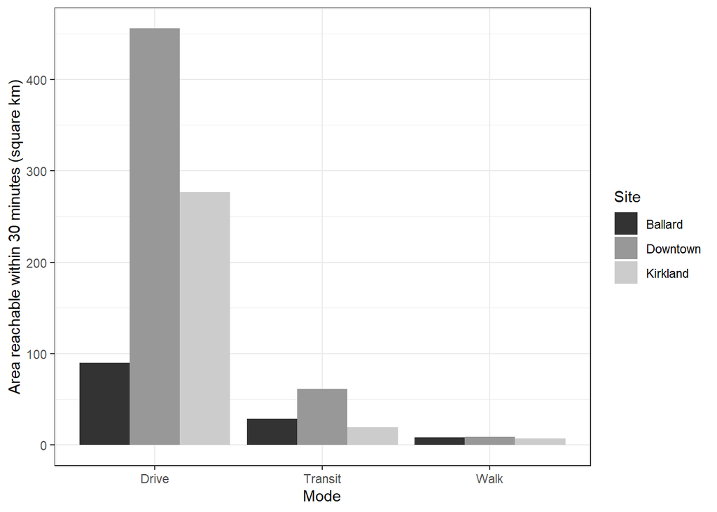

## Differences in proximity

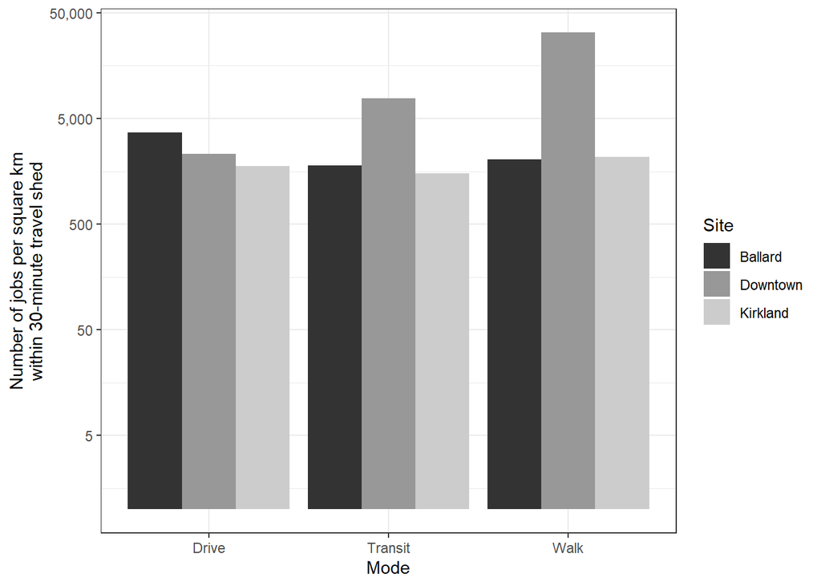

## Differences in accessibility

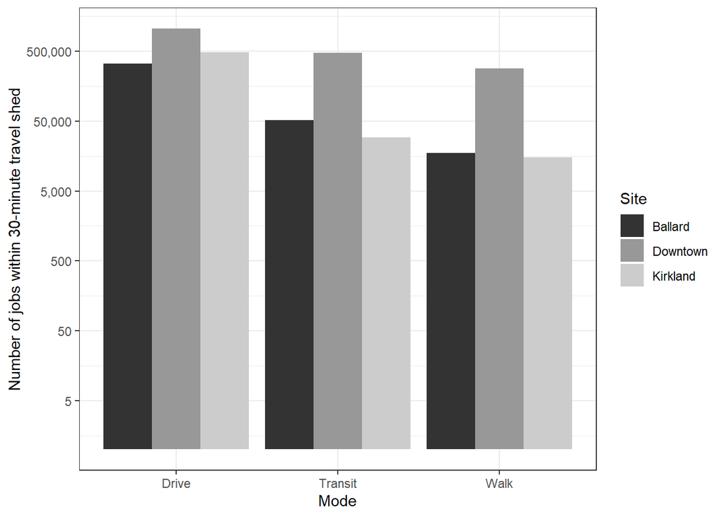